# Robert Carter 621 Final Project

Robert Carter

12/10/2018

The Problem: NFL teams battle an Sundays to determine who is the better team. The goal I would like to achieve isto dive into the data and determine what variables are significant to an NFL team chances of winnning by using runnning back data.

The Importance Of This Question: Determining this NFL teams can focus more on the significant variables and tailor their team to give them a higher chance at winning. IN return, winning cause more people to come to games and higher attendance could turn into higer profit.

```r
library(ggplot2)
library(lubridate)
library(tidyr)
library(ggthemes)
library(scales)
library(mlr)
library(readr)
library(dplyr)
library(stringr)
library(knitr)
library(openxlsx)
library(tree)
library(janitor)
library(car)
library(boot)
library(randomForest)
```

First I will start by loading the NFL data from a csv file in the predicitve folder

```r
mainNFL <- read.csv('~/Desktop/Predictive/project/nflstatistics/Game_Logs_Runningback.csv')
```

Next, I will run a summary to get a brief over view of the data. At first veiw there looks to be some fiels that need to be cleaned up. Especially those records with “–”.

```r
summary(mainNFL)
```

```
##                   Player.Id                   Name       Position
##  tonyrichardson/2502655:  282   Peterson, Adrian:  333     :56035
##  lorenzoneal/2502265   :  275   Richardson, Tony:  282   FB: 1636
##  marcusallen/2499399   :  250   Neal, Lorenzo   :  275   RB: 9990
##  frankgore/2506404     :  244   Allen, Marcus   :  250
##  fredtaylor/2503256    :  239   Gore, Frank     :  244
##  fredmcafee/2501935    :  235   Taylor, Fred    :  239
##  (Other)               :66136   (Other)         :66038
##       Year                 Season           Week          Game.Date
##  Min.   :1970   Postseason    : 2677   Min.   : 0.000   11/23  :  618
##  1st Qu.:1984   Preseason     : 6534   1st Qu.: 4.000   12/04  :  606
##  Median :1999   Pro Bowl      :  263   Median : 8.000   12/11  :  605
##  Mean   :1996   Regular Season:58187   Mean   : 8.511   11/22  :  604
##  3rd Qu.:2009                          3rd Qu.:13.000   09/18  :  596
##  Max.   :2016                          Max.   :23.000   12/14  :  591
##                                                         (Other):64041
##  Home.or.Away    Opponent     Outcome        Score        Games.Played
##  Away:33908   DAL    : 2385   L:33465   20 to 17:  625   Min.   :0.0000
##  Home:33753   WAS    : 2358   T:   53   17 to 20:  624   1st Qu.:1.0000
##               MIN    : 2349   W:34143   24 to 27:  498   Median :1.0000
##               GB     : 2322             23 to 20:  473   Mean   :0.8813
##               MIA    : 2315             20 to 23:  469   3rd Qu.:1.0000
##               SF     : 2313             27 to 24:  454   Max.   :1.0000
##               (Other):53619             (Other) :64518
##  Games.Started Rushing.Attempts Rushing.Yards   Yards.Per.Carry
##  --:24462      --     :27696    --     :27696   --     :27698
##  0 :29622      1      : 5250    2      : 1292   3.0    : 2053
##  1 :13577      2      : 3694    3      : 1255   2.0    : 1858
##                3      : 3051    4      : 1078   4.0    : 1710
##                4      : 2693    1      : 1053   1.0    : 1232
##                5      : 2379    5      :  999   5.0    : 1074
##                (Other):22898    (Other):34288   (Other):32036
##  Longest.Rushing.Run Rushing.TDs   Receptions    Receiving.Yards
##  --     :31052       --:27696    --     :35600   --     :35600
##  9      : 2406       0 :31521    1      :11976   0      : 2127
##  6      : 2255       1 : 6867    2      : 7485   6      : 1257
##  5      : 2176       2 : 1329    3      : 4521   9      : 1223
##  7      : 2176       3 :  225    4      : 2697   8      : 1201
##  8      : 2130       4 :   22    0      : 1720   7      : 1196
##  (Other):25466       5 :    1    (Other): 3662   (Other):25057
##  Yards.Per.Reception Longest.Reception Receiving.TDs Fumbles
##  --     :37320       --     :39430     --:35600      --:64442
##  6.0    : 1618       9      : 2078     0 :29636      1 : 2923
##  5.0    : 1544       8      : 1803     1 : 2320      2 :  280
##  7.0    : 1534       7      : 1694     2 :   97      3 :   16
##  4.0    : 1452       6      : 1654     3 :    7
##  8.0    : 1437       11     : 1591     4 :    1
##  (Other):22756       (Other):19411
##  Fumbles.Lost
##  --:64442
##  0 : 1380
##  1 : 1738
##  2 :   97
##  3 :    4
##
##
```

I also want to check the variable data types to make adjustments to any possible numeric fields since I am predicting a numeric field

```r
str(mainNFL)
```

```
## 'data.frame':    67661 obs. of  25 variables:
##  $ Player.Id          : Factor w/ 1256 levels "a.j.harris/2507016",..: 111 111 111 111 111 111 111 111 111 111 ...
##  $ Name               : Factor w/ 1247 levels "Abdullah, Ameer",..: 391 391 391 391 391 391 391 391 391 391 ...
##  $ Position           : Factor w/ 3 levels "","FB","RB": 1 1 1 1 1 1 1 1 1 1 ...
##  $ Year               : int  1985 1985 1985 1985 1985 1985 1985 1985 1985 1985 ...
##  $ Season             : Factor w/ 4 levels "Postseason","Preseason",..: 4 4 4 4 4 4 4 4 4 4 ...
##  $ Week               : int  7 8 9 10 11 12 13 14 15 16 ...
##  $ Game.Date          : Factor w/ 194 levels "01/01","01/02",..: 122 129 136 143 150 157 164 171 178 185 ...
##  $ Home.or.Away       : Factor w/ 2 levels "Away","Home": 1 2 1 2 1 1 2 1 2 2 ...
##  $ Opponent           : Factor w/ 43 levels "APR","ARI","ATL",..: 3 27 34 38 15 23 34 40 39 3 ...
##  $ Outcome            : Factor w/ 3 levels "L","T","W": 1 1 1 1 1 3 3 1 1 1 ...
##  $ Score              : Factor w/ 1828 levels "0 to 10","0 to 11",..: 668 174 68 917 237 960 883 313 442 56 ...
##  $ Games.Played       : int  1 1 1 1 1 1 1 1 1 1 ...
##  $ Games.Started      : Factor w/ 3 levels "--","0","1": 1 1 1 1 1 1 1 1 1 1 ...
##  $ Rushing.Attempts   : Factor w/ 45 levels "--","0","1","10",..: 1 1 1 1 3 1 1 1 1 3 ...
##  $ Rushing.Yards      : Factor w/ 261 levels "--","-1","-10",..: 1 1 1 1 18 1 1 1 1 185 ...
##  $ Yards.Per.Carry    : Factor w/ 267 levels "--","-0.1","-0.2",..: 1 1 1 1 47 1 1 1 1 170 ...
##  $ Longest.Rushing.Run: Factor w/ 192 levels "--","-1","-11",..: 1 1 1 1 14 1 1 1 1 58 ...
##  $ Rushing.TDs        : Factor w/ 7 levels "--","0","1","2",..: 1 1 1 1 2 1 1 1 1 2 ...
##  $ Receptions         : Factor w/ 18 levels "--","0","1","10",..: 1 1 12 1 1 1 1 1 1 11 ...
##  $ Receiving.Yards    : Factor w/ 174 levels "--","-1","-10",..: 1 1 95 1 1 1 1 1 1 75 ...
##  $ Yards.Per.Reception: Factor w/ 348 levels "--","-0.3","-0.5",..: 1 1 336 1 1 1 1 1 1 325 ...
##  $ Longest.Reception  : Factor w/ 185 levels "--","-1","-10",..: 1 1 19 1 1 1 1 1 1 21 ...
##  $ Receiving.TDs      : Factor w/ 6 levels "--","0","1","2",..: 1 1 2 1 1 1 1 1 1 2 ...
##  $ Fumbles            : Factor w/ 4 levels "--","1","2","3": 1 1 1 1 1 1 1 1 1 1 ...
##  $ Fumbles.Lost       : Factor w/ 5 levels "--","0","1","2",..: 1 1 1 1 1 1 1 1 1 1 ...
```

I will create the score margin, score team, and score opponent variables first before I clean the data. I do not want to delte a row unnecessarily.

```r
mainNFL$Score.Team = as.integer(sapply(strsplit(as.character(mainNFL$Score), " to "), "[[", 1))
mainNFL$Score.Opp = as.integer(sapply(strsplit(as.character(mainNFL$Score), " to "), "[[", 2))
mainNFL$Score.Margin = mainNFL$Score.Team - mainNFL$Score.Opp
```

I will do a quick check of the first ten rows of data to look at the newly created vairables. After that, I will remove all of the rows that contain ‘–’ and replace them with zeros.

```r
head(mainNFL,10)
```

```
##              Player.Id          Name Position Year         Season Week
## 1  bobbyfowler/2514295 Fowler, Bobby          1985 Regular Season    7
## 2  bobbyfowler/2514295 Fowler, Bobby          1985 Regular Season    8
## 3  bobbyfowler/2514295 Fowler, Bobby          1985 Regular Season    9
## 4  bobbyfowler/2514295 Fowler, Bobby          1985 Regular Season   10
## 5  bobbyfowler/2514295 Fowler, Bobby          1985 Regular Season   11
## 6  bobbyfowler/2514295 Fowler, Bobby          1985 Regular Season   12
## 7  bobbyfowler/2514295 Fowler, Bobby          1985 Regular Season   13
## 8  bobbyfowler/2514295 Fowler, Bobby          1985 Regular Season   14
## 9  bobbyfowler/2514295 Fowler, Bobby          1985 Regular Season   15
## 10 bobbyfowler/2514295 Fowler, Bobby          1985 Regular Season   16
##    Game.Date Home.or.Away Opponent Outcome    Score Games.Played
## 1      10/20         Away      ATL       L 24 to 31            1
## 2      10/27         Home      NYG       L 13 to 21            1
## 3      11/03         Away      RAM       L 10 to 28            1
```

[output cut: 51 more lines]

```r
mainNFL <- mainNFL[mainNFL != '--', ]
mainNFL[mainNFL == '--'] <- '0'
```

Reformatting names so it will give the variables a more uniform naming style.

```r
names(mainNFL) <- tolower(gsub("\\.", "_", names(mainNFL)))
names(mainNFL) <- gsub("\\(", "", names(mainNFL))
names(mainNFL) <- gsub("\\)", "", names(mainNFL))
```

Transforming character variable data types to numeric data types for regression modeling.

```r
for (k in c( 'games_played', 'games_started', 'rushing_attempts', 'rushing_yards',
            'yards_per_carry', 'longest_rushing_run', 'rushing_tds', 'receptions',
            'receiving_yards', 'yards_per_reception', 'longest_reception',
            'receiving_tds', 'fumbles', 'fumbles_lost', 'score_team', 'score_opp', 'score_margin')){
  mainNFL[ , k] = as.numeric(as.character(mainNFL[, k]))
}
```

Finally, checking for unique values in variable fields and also checking for NA’s in the dataset. Since there are NA’s left, I will remove them and it should help when I start the prediction process.

```r
unique(mainNFL$games_played)
```

```
## [1]  1  0 NA
```

```r
#is.na(mainNFL$fumbles)
#is.na(mainNFL$rushing_yards)
mainNFL <- na.omit(mainNFL)
```

I am filtering the data to only include regular season and post season data. Players typically play harder during these two seasons. Then I will review the first 10 rows.

```r
mainNFL <- filter(mainNFL, season %in% c("Regular Season", "Postseason"))
head(mainNFL, 10)
```

```
##                  player_id              name position year         season
## 1  darylrichardson/2534789 Richardson, Daryl       RB 2012 Regular Season
## 2  darylrichardson/2534789 Richardson, Daryl       RB 2012 Regular Season
## 3  darylrichardson/2534789 Richardson, Daryl       RB 2012 Regular Season
## 4       bradbaxter/2499579      Baxter, Brad          1993 Regular Season
## 5       bradbaxter/2499579      Baxter, Brad          1993 Regular Season
## 6       bradbaxter/2499579      Baxter, Brad          1993 Regular Season
## 7       bradbaxter/2499579      Baxter, Brad          1992 Regular Season
## 8       bradbaxter/2499579      Baxter, Brad          1991 Regular Season
## 9       mariobates/2499570      Bates, Mario          1996 Regular Season
## 10      mariobates/2499570      Bates, Mario          1996 Regular Season
##    week game_date home_or_away opponent outcome    score games_played
## 1     2     09/16         Home      WAS       W 31 to 28            1
## 2     8     10/28         Home       NE       L  7 to 45            1
## 3    11     11/18         Home      NYJ       L 13 to 27            1
```

[output cut: 51 more lines]

I am building an intial regression model with all fields except score team and score_opp

```r
lm.nfl <- lm(score_margin ~ . -score_opp - score_team , data = mainNFL)
summary(lm.nfl)
```

```
##
## Call:
## lm(formula = score_margin ~ . - score_opp - score_team, data = mainNFL)
##
## Residuals:
##        Min         1Q     Median         3Q        Max
## -2.212e-12 -6.082e-14  0.000e+00  6.488e-14  2.872e-12
##
## Coefficients: (347 not defined because of singularities)
##                                        Estimate Std. Error    t value
## (Intercept)                          -2.300e+01  1.730e-11 -1.329e+12
## player_idadrianpeterson/2505173       1.100e+01  9.114e-13  1.207e+13
## player_idadrianpeterson/2507164       1.100e+01  8.435e-13  1.304e+13
## player_idahmardhall/2507007           1.100e+01  9.246e-13  1.190e+13
## player_idalexcollins/2555430          1.100e+01  9.736e-13  1.130e+13
## player_idalfredblue/2543600           1.100e+01  1.070e-12  1.028e+13
## player_idalfredmorris/2533457         1.100e+01  8.655e-13  1.271e+13
## player_idallenpinkett/2502487         1.100e+01  9.764e-13  1.127e+13
## player_idallenrice/2502641            1.100e+01  9.846e-13  1.117e+13
## player_idalvinpearman/2506464         1.100e+01  8.994e-13  1.223e+13
## player_idameerabdullah/2552374        1.100e+01  9.241e-13  1.190e+13
## player_idamoszereoue/2503858          1.100e+01  8.784e-13  1.252e+13
## player_idamplee/2501715               1.100e+01  8.758e-13  1.256e+13
## player_idandrewpinnock/2505457        1.100e+01  9.775e-13  1.125e+13
## player_idanthonydixon/497172          1.600e+01  1.001e-12  1.598e+13
## player_idanthonyjohnson/2501409       1.100e+01  8.723e-13  1.261e+13
## player_idanthonysherman/2495340       1.100e+01  9.835e-13  1.118e+13
## player_idanthonythomas/2504657        1.100e+01  8.788e-13  1.252e+13
## player_idanthonythompson/2527308      1.100e+01  9.707e-13  1.133e+13
## player_idantoniopittman/2495711       1.100e+01  1.155e-12  9.522e+12
## player_idarianfoster/79555            1.100e+01  8.479e-13  1.297e+13
## player_idarlenharris/2505379          1.100e+01  9.157e-13  1.201e+13
## player_idartosepinner/2505518         1.100e+01  9.917e-13  1.109e+13
## player_idautrydenson/2500369          1.100e+01  9.934e-13  1.107e+13
## player_idaveioncason/2504353          1.100e+01  9.613e-13  1.144e+13
## player_idbarryfoster/2500688          1.100e+01  8.835e-13  1.245e+13
## player_idbarrysanders/2502817         1.100e+01  8.691e-13  1.266e+13
## player_idbeaniewells/79661            1.100e+01  8.911e-13  1.234e+13
## player_idbennycunningham/2541544      1.100e+01  8.765e-13  1.255e+13
## player_idbentate/497208               1.100e+01  8.730e-13  1.260e+13
```

[output cut: 3174 more lines]

```
## longest_rushing_run                  0.372931
## rushing_tds                          0.653761
## receptions                           0.043663 *
## receiving_yards                      0.015043 *
## yards_per_reception                  0.274118
## longest_reception                    0.138694
## receiving_tds                        0.648073
## fumbles                              0.164679
## fumbles_lost                         0.976377
## ---
## Signif. codes:  0 '***' 0.001 '**' 0.01 '*' 0.05 '.' 0.1 ' ' 1
##
## Residual standard error: 4.064e-13 on 621 degrees of freedom
## Multiple R-squared:      1,  Adjusted R-squared:      1
## F-statistic: 1.907e+27 on 1258 and 621 DF,  p-value: < 2.2e-16
```

Built another regression model to exclude spme of the nosier data points to get a clearer regression model.

```r
lm.nfl2 <- lm(score_margin ~ . -score - name - player_id - game_date - opponent - score_opp - score_team - outcome , data = mainNFL)
summary(lm.nfl2)
```

```
##
## Call:
## lm(formula = score_margin ~ . - score - name - player_id - game_date -
##     opponent - score_opp - score_team - outcome, data = mainNFL)
##
## Residuals:
##     Min      1Q  Median      3Q     Max
## -53.642  -8.261   0.282   8.194  41.688
##
## Coefficients: (1 not defined because of singularities)
##                       Estimate Std. Error t value Pr(>|t|)
## (Intercept)           84.37932  114.11629   0.739  0.45975
## positionFB            -5.41622    3.60237  -1.504  0.13288
## positionRB            -0.71668    0.98757  -0.726  0.46811
## year                  -0.04054    0.05703  -0.711  0.47732
## seasonRegular Season  -3.12200    1.49975  -2.082  0.03751 *
## week                  -0.17252    0.06122  -2.818  0.00489 **
## home_or_awayHome       5.01768    0.60734   8.262 2.69e-16 ***
## games_played                NA         NA      NA       NA
## games_started         -6.07664    0.80657  -7.534 7.64e-14 ***
## rushing_attempts       0.39712    0.08877   4.474 8.16e-06 ***
## rushing_yards          0.03006    0.02105   1.428  0.15334
## yards_per_carry       -0.02893    0.17978  -0.161  0.87218
## longest_rushing_run   -0.02081    0.04596  -0.453  0.65076
## rushing_tds            3.50359    0.55076   6.361 2.51e-10 ***
## receptions            -1.64163    0.35794  -4.586 4.81e-06 ***
## receiving_yards        0.11928    0.04628   2.577  0.01003 *
## yards_per_reception    0.05740    0.10911   0.526  0.59890
## longest_reception     -0.14730    0.07141  -2.063  0.03926 *
## receiving_tds          5.26498    1.41751   3.714  0.00021 ***
## fumbles               -0.34925    0.96655  -0.361  0.71789
## fumbles_lost          -2.89124    0.57356  -5.041 5.08e-07 ***
## ---
## Signif. codes:  0 '***' 0.001 '**' 0.01 '*' 0.05 '.' 0.1 ' ' 1
##
## Residual standard error: 13.09 on 1860 degrees of freedom
## Multiple R-squared:  0.1963, Adjusted R-squared:  0.1881
## F-statistic: 23.91 on 19 and 1860 DF,  p-value: < 2.2e-16
```

```r
lm.nfl3 <- lm(score_margin ~ position + year + season + home_or_away + games_started +rushing_yards + rushing_tds + receptions + receiving_yards + longest_reception + receiving_tds + fumbles_lost, data = mainNFL)
summary(lm.nfl3)
```

```
##
## Call:
## lm(formula = score_margin ~ position + year + season + home_or_away +
##     games_started + rushing_yards + rushing_tds + receptions +
##     receiving_yards + longest_reception + receiving_tds + fumbles_lost,
##     data = mainNFL)
##
## Residuals:
##     Min      1Q  Median      3Q     Max
## -54.046  -8.333   0.489   8.429  42.607
##
## Coefficients:
##                        Estimate Std. Error t value Pr(>|t|)
## (Intercept)           59.062749 114.721642   0.515 0.606729
## positionFB            -5.817480   3.627365  -1.604 0.108933
## positionRB            -1.176892   0.990413  -1.188 0.234873
## year                  -0.029053   0.057341  -0.507 0.612453
## seasonRegular Season  -1.443727   1.366924  -1.056 0.291019
## home_or_awayHome       5.141808   0.612472   8.395  < 2e-16 ***
## games_started         -4.367658   0.758134  -5.761 9.76e-09 ***
## rushing_yards          0.081495   0.008793   9.268  < 2e-16 ***
## rushing_tds            3.823693   0.550042   6.952 4.97e-12 ***
## receptions            -1.728537   0.296739  -5.825 6.71e-09 ***
## receiving_yards        0.124500   0.042631   2.920 0.003538 **
## longest_reception     -0.119133   0.063138  -1.887 0.059333 .
## receiving_tds          5.328101   1.427591   3.732 0.000195 ***
## fumbles_lost          -2.966059   0.550605  -5.387 8.08e-08 ***
## ---
## Signif. codes:  0 '***' 0.001 '**' 0.01 '*' 0.05 '.' 0.1 ' ' 1
##
## Residual standard error: 13.21 on 1866 degrees of freedom
## Multiple R-squared:  0.1784, Adjusted R-squared:  0.1727
## F-statistic: 31.17 on 13 and 1866 DF,  p-value: < 2.2e-16
```

```r
anova(lm.nfl, lm.nfl2)
```

```
## Analysis of Variance Table
##
## Model 1: score_margin ~ (player_id + name + position + year + season +
##     week + game_date + home_or_away + opponent + outcome + score +
##     games_played + games_started + rushing_attempts + rushing_yards +
##     yards_per_carry + longest_rushing_run + rushing_tds + receptions +
##     receiving_yards + yards_per_reception + longest_reception +
##     receiving_tds + fumbles + fumbles_lost + score_team + score_opp) -
##     score_opp - score_team
## Model 2: score_margin ~ (player_id + name + position + year + season +
##     week + game_date + home_or_away + opponent + outcome + score +
##     games_played + games_started + rushing_attempts + rushing_yards +
##     yards_per_carry + longest_rushing_run + rushing_tds + receptions +
##     receiving_yards + yards_per_reception + longest_reception +
##     receiving_tds + fumbles + fumbles_lost + score_team + score_opp) -
##     score - name - player_id - game_date - opponent - score_opp -
##     score_team - outcome
##   Res.Df    RSS    Df Sum of Sq          F    Pr(>F)
## 1    621      0
## 2   1860 318490 -1239   -318490 1.5561e+27 < 2.2e-16 ***
## ---
## Signif. codes:  0 '***' 0.001 '**' 0.01 '*' 0.05 '.' 0.1 ' ' 1
```

```r
anova(lm.nfl2, lm.nfl3)
```

```
## Analysis of Variance Table
##
## Model 1: score_margin ~ (player_id + name + position + year + season +
##     week + game_date + home_or_away + opponent + outcome + score +
##     games_played + games_started + rushing_attempts + rushing_yards +
##     yards_per_carry + longest_rushing_run + rushing_tds + receptions +
##     receiving_yards + yards_per_reception + longest_reception +
##     receiving_tds + fumbles + fumbles_lost + score_team + score_opp) -
##     score - name - player_id - game_date - opponent - score_opp -
##     score_team - outcome
## Model 2: score_margin ~ position + year + season + home_or_away + games_started +
##     rushing_yards + rushing_tds + receptions + receiving_yards +
##     longest_reception + receiving_tds + fumbles_lost
##   Res.Df    RSS Df Sum of Sq      F    Pr(>F)
## 1   1860 318490
## 2   1866 325568 -6   -7077.3 6.8886 2.999e-07 ***
## ---
## Signif. codes:  0 '***' 0.001 '**' 0.01 '*' 0.05 '.' 0.1 ' ' 1
```

Ran a VIF test to see if there was any multicollinearity. There was one field (receiving yards) that was over five and it showed that variable was multicollinear.

```r
vif(lm.nfl3)
```

```
##                       GVIF Df GVIF^(1/(2*Df))
## position          2.084928  2        1.201636
## year              2.080051  1        1.442238
## season            1.004385  1        1.002190
## home_or_away      1.010418  1        1.005195
## games_started     1.253759  1        1.119714
## rushing_yards     1.407571  1        1.186411
## rushing_tds       1.197383  1        1.094250
## receptions        3.873949  1        1.968235
## receiving_yards   8.379209  1        2.894686
## longest_reception 3.900979  1        1.975090
## receiving_tds     1.062662  1        1.030855
## fumbles_lost      1.011670  1        1.005818
```

In the last regression model I removed the field that showed multicollinearity. There are only 5 variables that have a possitive correlation to the model. 4 of those variables are strongly significant.

```r
lm.nfl4 <- lm(score_margin ~ position + year + season + home_or_away + games_started +rushing_yards + rushing_tds + receptions  + longest_reception + receiving_tds + fumbles_lost, data = mainNFL)
summary(lm.nfl4)
```

```
##
## Call:
## lm(formula = score_margin ~ position + year + season + home_or_away +
##     games_started + rushing_yards + rushing_tds + receptions +
##     longest_reception + receiving_tds + fumbles_lost, data = mainNFL)
##
## Residuals:
##     Min      1Q  Median      3Q     Max
## -54.011  -8.226   0.389   8.372  42.891
##
## Coefficients:
##                        Estimate Std. Error t value Pr(>|t|)
## (Intercept)           77.125129 114.785534   0.672 0.501726
## positionFB            -5.619984   3.634040  -1.546 0.122157
## positionRB            -1.006263   0.990680  -1.016 0.309890
## year                  -0.038675   0.057362  -0.674 0.500249
## seasonRegular Season  -1.417413   1.369647  -1.035 0.300862
## home_or_awayHome       5.181994   0.613551   8.446  < 2e-16 ***
## games_started         -4.451545   0.759115  -5.864 5.33e-09 ***
## rushing_yards          0.080425   0.008803   9.136  < 2e-16 ***
## rushing_tds            3.881414   0.550794   7.047 2.56e-12 ***
## receptions            -1.007169   0.164766  -6.113 1.19e-09 ***
## longest_reception      0.035796   0.034303   1.044 0.296838
## receiving_tds          5.544134   1.428545   3.881 0.000108 ***
## fumbles_lost          -2.930261   0.551577  -5.313 1.21e-07 ***
## ---
## Signif. codes:  0 '***' 0.001 '**' 0.01 '*' 0.05 '.' 0.1 ' ' 1
##
## Residual standard error: 13.24 on 1867 degrees of freedom
## Multiple R-squared:  0.1747, Adjusted R-squared:  0.1694
## F-statistic: 32.93 on 12 and 1867 DF,  p-value: < 2.2e-16
```

Ran one last multicollinearity check on data before moving forward witih the glm model. There is no multicollinearity.

```r
vif(lm.nfl4)
```

```
##                       GVIF Df GVIF^(1/(2*Df))
## position          2.077492  2        1.200563
## year              2.073183  1        1.439855
## season            1.004342  1        1.002169
## home_or_away      1.009908  1        1.004942
## games_started     1.251959  1        1.118910
## rushing_yards     1.405130  1        1.185382
## rushing_tds       1.195836  1        1.093543
## receptions        1.189583  1        1.090680
## longest_reception 1.146860  1        1.070916
## receiving_tds     1.059809  1        1.029470
## fumbles_lost      1.011169  1        1.005569
```

Ran a glm regression model to calculate the k-fold prediction error. There is not much difference in the leave one out and the 10 fold cross validation model. There isn’t much variance in either model.

```r
my.glm = glm(score_margin ~ position + year + season + home_or_away + games_started +rushing_yards + rushing_tds + receptions + longest_reception + receiving_tds + fumbles_lost, data = mainNFL)
summary(my.glm)
```

```
##
## Call:
## glm(formula = score_margin ~ position + year + season + home_or_away +
##     games_started + rushing_yards + rushing_tds + receptions +
##     longest_reception + receiving_tds + fumbles_lost, data = mainNFL)
##
## Deviance Residuals:
##     Min       1Q   Median       3Q      Max
## -54.011   -8.226    0.389    8.372   42.891
##
## Coefficients:
##                        Estimate Std. Error t value Pr(>|t|)
## (Intercept)           77.125129 114.785534   0.672 0.501726
## positionFB            -5.619984   3.634040  -1.546 0.122157
## positionRB            -1.006263   0.990680  -1.016 0.309890
## year                  -0.038675   0.057362  -0.674 0.500249
## seasonRegular Season  -1.417413   1.369647  -1.035 0.300862
## home_or_awayHome       5.181994   0.613551   8.446  < 2e-16 ***
## games_started         -4.451545   0.759115  -5.864 5.33e-09 ***
## rushing_yards          0.080425   0.008803   9.136  < 2e-16 ***
## rushing_tds            3.881414   0.550794   7.047 2.56e-12 ***
## receptions            -1.007169   0.164766  -6.113 1.19e-09 ***
## longest_reception      0.035796   0.034303   1.044 0.296838
## receiving_tds          5.544134   1.428545   3.881 0.000108 ***
## fumbles_lost          -2.930261   0.551577  -5.313 1.21e-07 ***
## ---
## Signif. codes:  0 '***' 0.001 '**' 0.01 '*' 0.05 '.' 0.1 ' ' 1
##
## (Dispersion parameter for gaussian family taken to be 175.1771)
##
##     Null deviance: 396276  on 1879  degrees of freedom
## Residual deviance: 327056  on 1867  degrees of freedom
## AIC: 15062
##
## Number of Fisher Scoring iterations: 2
```

```r
cv.glm(mainNFL,my.glm)$delta[1]
```

```
## [1] 176.3331
```

```r
cv.glm(mainNFL,my.glm, K=10)$delta[1]
```

```
## [1] 175.854
```

Now I am breaking data into train and testing datasets

```r
set.seed(1)
train = sample(1:nrow(mainNFL), 0.75*nrow(mainNFL))
nfl.train = mainNFL[train, ]
nfl.test = mainNFL[-train, ]
```

Creating a regression tree to look at the most important vairables for predicting score_margin. Rushing TD’s look to be the most important vairable for predicting using the refression tree model with the train data.

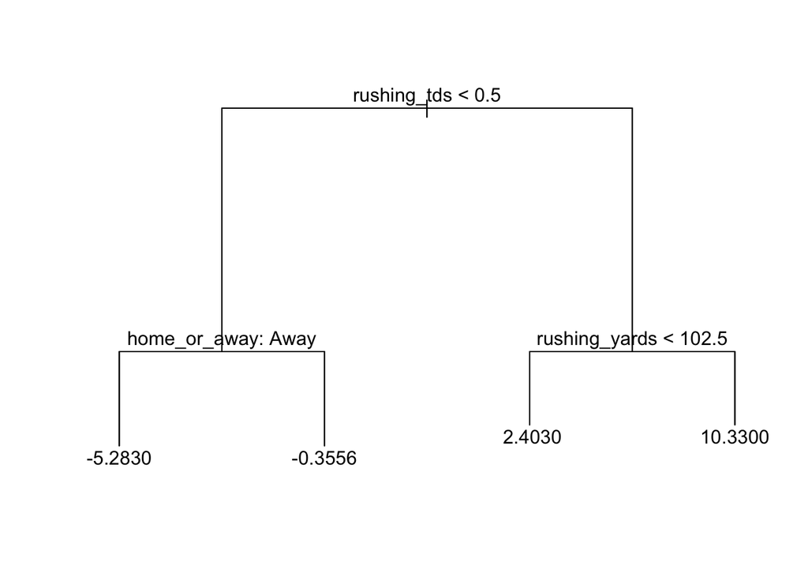

```r
my.reg.tree = tree(score_margin ~ position + year + season + home_or_away + games_started +rushing_yards + rushing_tds + receptions + longest_reception + receiving_tds + fumbles_lost, data = nfl.train)
plot(my.reg.tree)
text(my.reg.tree, pretty =0)
```

Created a second regression tree using the test data set.There doesn’t appear to be a clear standout variable in this model. However, home away is the first variable in the tree and rushing yards appear twice.

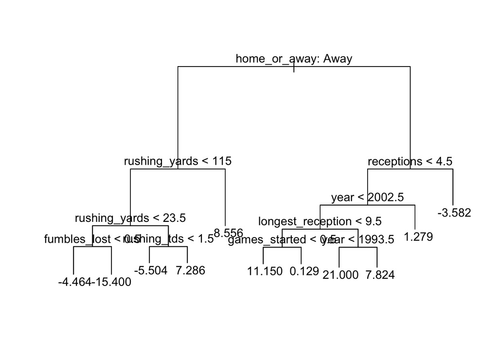

```r
my.reg.tree2 = tree(score_margin ~ position + year + season + home_or_away + games_started +rushing_yards + rushing_tds + receptions +  longest_reception + receiving_tds + fumbles_lost, data = nfl.test)
plot(my.reg.tree2)
text(my.reg.tree2, pretty =0)
```

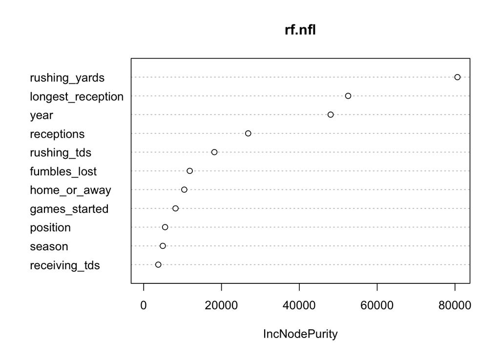

```r
rf.nfl = randomForest(score_margin ~ position + year + season + home_or_away + games_started +rushing_yards + rushing_tds + receptions + longest_reception + receiving_tds + fumbles_lost, data = nfl.train, mtry = 10)
varImpPlot(rf.nfl)
```

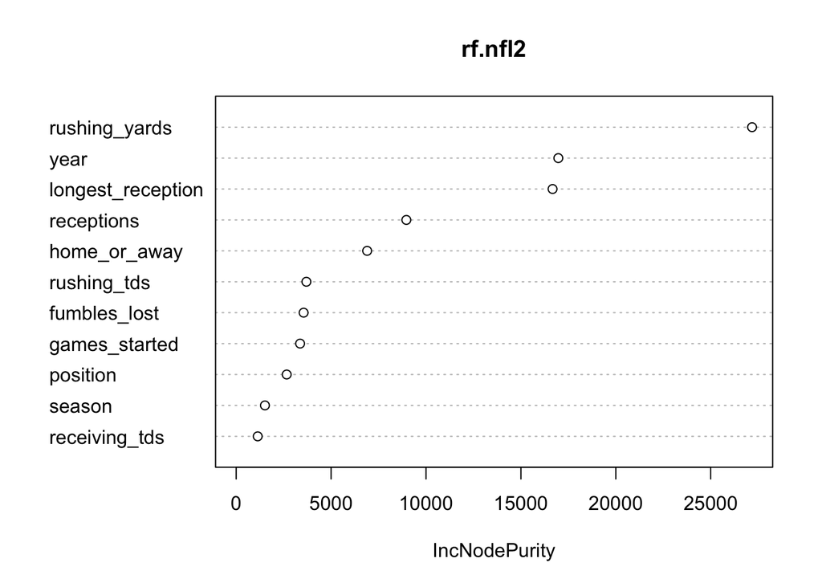

```r
rf.nfl2 = randomForest(score_margin ~ position + year + season + home_or_away + games_started +rushing_yards + rushing_tds + receptions + longest_reception + receiving_tds + fumbles_lost, data = nfl.test, mtry = 10)
varImpPlot(rf.nfl2)
```

For my last model I will create a new data frame and check the error rate of the model by creating a dummy variable to predict wins.

```r
mainNFL2 <- select(mainNFL, score_margin, position, year, season, home_or_away, games_started, rushing_yards, rushing_tds, receptions, longest_reception, receiving_tds, fumbles_lost)

mainNFL2$win = as.factor(ifelse(mainNFL2$score_margin > 0,1,0))
```

I am creating a new training and testing data set.

```r
set.seed(1)
train = sample(1:nrow(mainNFL2), 0.75*nrow(mainNFL2))
mainNFL2.train = mainNFL2[train, ]
mainNFL2.test = mainNFL2[-train, ]
```

Going to start with a classification tree and then create a train and test data for probability and predcitons. Setting both thresholds to 50 percent.

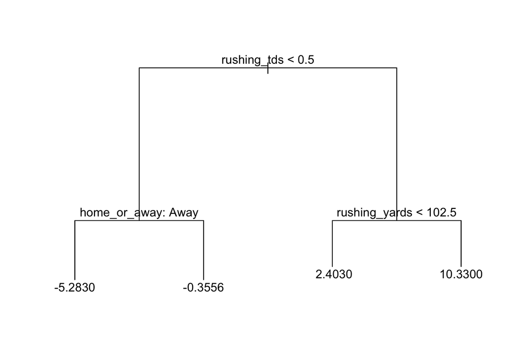

```r
my.class.tree = tree(win ~ . -score_margin, data = mainNFL2.train)
plot(my.reg.tree)
text(my.reg.tree, pretty =0)
```

```r
prob.train = predict(my.class.tree, newdata=mainNFL2.train)[,2]
prob.test = predict(my.class.tree, newdata=mainNFL2.test)[,2]

pred.train = ifelse(prob.train >= 0.5, 1, 0)
pred.test = ifelse(prob.test >= 0.5, 1, 0)
```

```r
conf.train = table(pred.train, mainNFL2.train$win)
conf.test = table(pred.test, mainNFL2.test$win)
error.train = 1 - sum(diag(conf.train)) / sum(conf.train)
error.train
```

```
## [1] 0.387234
```

```r
error.test = 1 - sum(diag(conf.test)) / sum(conf.test)
error.test
```

```
## [1] 0.4042553
```

In conclusion in order to predict scrore margin the best predictor is rushing yards. If we were to go accroding to the regression tree the next best predictor would be rushing touchdowns. However, the random foresst model says longest reception is the next best variable. I believe that rushing yards and rushing touch downs are the two best. Those variables are highly significant.